# TEgenomeSimulator Surrogate Modelling

This tutorial will cover the development of surrogate models, and the potential applications of such models. A surrogate model is an approximate model used to emulate a more expensive or complex simulation. It is trained on input-output data from the original model to predict outcomes quickly. Surrogate models are commonly used in optimisation, uncertainty quantification, and sensitivity analysis to reduce computational costs.

[A very informative e-book on surrogate modelling can be found here](https://bookdown.org/rbg/surrogates/).

# Imports

We will first import all required dependencies and specify our constants.

```python
import pandas as pd
import numpy as np
import os.path as osp
from subprocess import Popen
import subprocess
from pathlib import Path
import shutil

from calisim.data_model import (
	DistributionModel,
	ParameterDataType,
	ParameterSpecification,
)
from calisim.sensitivity import (
	SensitivityAnalysisMethod,
	SensitivityAnalysisMethodModel,
)
from calisim.surrogate import (
	SurrogateModelMethod,
	SurrogateModelMethodModel,
)

M = 0
c = str(Path("data", "random_genome_chr_index.csv"))
r = str(Path("data", "combined_curated_TE_lib_ATOSZM_selected.fasta"))
o="data"
m = 2
n = 2
seed = 100
```

# Calibration procedure

## Surrogate Modelling

We will next train a surrogate model for a sensitivity analysis. Again, we will focus on the analysis of the mean sequence identity for each TE family.

For this exercise, there are four parameters of interest within TEgenomeSimulator:

- **maxidn**: The upper bound of mean sequence identity to be sampled for each TE family (default is 95; i.e. 95 percent).
- **minidn**: The lower bound of mean sequence identity to be sampled for each TE family (default is 80; i.e. 80 percent).
- **maxsd**: The upper bound of standard deviation of mean identity to be sampled for each TE family (default is 20).
- **minsd**: The lower bound of standard deviation of mean identity to be sampled for each TE family (default is 1).

We will first specify our parameter distributions:

```python
parameter_spec = ParameterSpecification(
    parameters=[
        DistributionModel(
            name="maxidn",
            distribution_name="uniform",
            distribution_args=[90, 95],
            data_type=ParameterDataType.DISCRETE,
        ),
        DistributionModel(
            name="minidn",
            distribution_name="uniform",
            distribution_args=[75, 85],
            data_type=ParameterDataType.DISCRETE,
        )
    ]
)
```

We will next define our sensitivity analysis function. We will run TEgenomeSimulator in mode 0, and subsequently extract the distribution of sampled mean sequence identities for each TE families. We'll take the average of the distribution of sampled identities across all TE families.

```python
def sensitivity_func(
	parameters: dict, simulation_id: str, observed_data: np.ndarray | None
) -> float | list[float]:
    maxidn = parameters["maxidn"]
    minidn = parameters["minidn"]
    maxsd = 20
    minsd = 1

    p = simulation_id

    cmd = f"tegenomesimulator -M {M} -p {p} -c {c} -r {r} -o {o} -m {m} -n {n} --maxidn {maxidn} --minidn {minidn} --maxsd {maxsd} --minsd {minsd} -s {seed}"
    Popen(cmd, shell=True, stdout=subprocess.DEVNULL, stderr=subprocess.DEVNULL).wait()

    repeat_annotation_path = f"{o}/TEgenomeSimulator_{p}_result/{p}_repeat_annotation_out_final.gff"
    df = pd.read_csv(repeat_annotation_path, sep="\t", header=None)
    shutil.rmtree(f"{o}/TEgenomeSimulator_{p}_result")

    mean_identity = df.iloc[:, 8].str.split(";").str[3].str.replace("Identity=", "").astype("float").mean()
    return mean_identity
```

$$ Y \approx \hat{Y} = \sum_{i} c_{\mathbf{\alpha}_i} \Psi_{\mathbf{\alpha}_i}(\mathbf{X}) $$

- $\Psi_{\mathbf{\alpha}_i}(\mathbf{X})$ are orthogonal polynomials of the inputs.
- $c_{\mathbf{\alpha}_i}$ are expansion coefficients.
- $i$ indexes the polynomial terms.

```
<calisim.sensitivity.implementation.SensitivityAnalysisMethod at 0x7f48a6c41090>
```

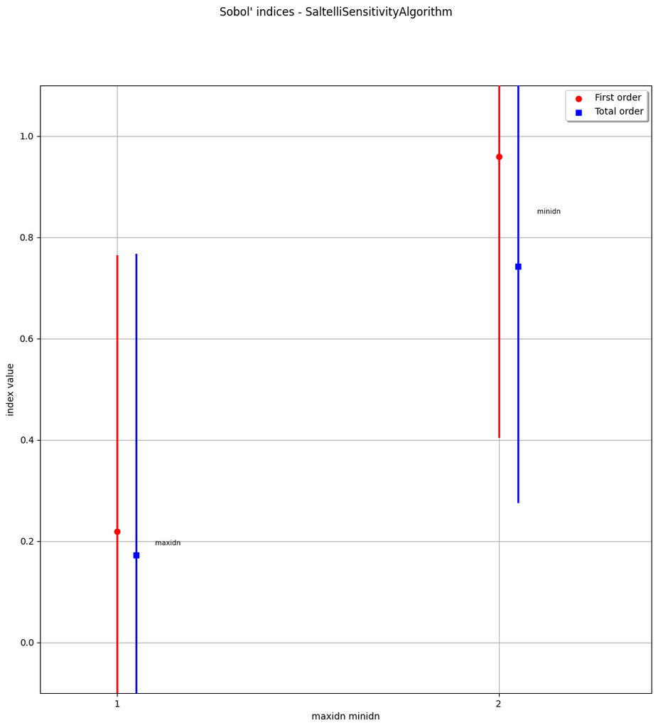

```python
specification = SensitivityAnalysisMethodModel(
	experiment_name="openturns_sensitivity_analysis",
	parameter_spec=parameter_spec,
	method="saltelli",
	#n_samples=32,
    n_samples=8,
    order=2,
    n_jobs=10,
    output_labels=["Mean Sequence Identities"],
	verbose=True,
	batched=False,

)

calibrator = SensitivityAnalysisMethod(
	calibration_func=sensitivity_func, specification=specification, engine="openturns"
)

calibrator.specify().execute().analyze()
```

```python
pd.DataFrame({
    "parameter_names": ["maxidn", "minidn"],
    "first_order": list(calibrator.implementation.first_order),
    "total_order": list(calibrator.implementation.total_order)
})
```

|  | parameter_names | first_order | total_order |
| --- | --- | --- | --- |
| 0 | maxidn | 0.218797 | 0.172525 |
| 1 | minidn | 0.959078 | 0.742051 |

We'll next make use of an alternative method to performing a surrogate-based sensitivity analysis via an approach that is more commonly applied within machine learning. We will use [SHapley Additive exPlanations (SHAP)](https://christophm.github.io/interpretable-ml-book/shapley.html) for both a local and global sensitivity analysis.

SHAP works by treating each feature like a player in a game trying to earn the model's prediction. For every possible subset of features, it asks: "If I add this feature, how much does it change the prediction?" Then it averages that contribution over all possible feature combinations thereby giving each feature its fair share of the prediction.

[We'll next fit a Gaussian process surrogate model using scikit-learn](https://scikit-learn.org/stable/modules/generated/sklearn.gaussian_process.GaussianProcessRegressor.html#sklearn.gaussian_process.GaussianProcessRegressor). There are several advantages to using a Gaussian process as the surrogate:

- **Quantifies uncertainty:** Each prediction provides both a mean and variance.
- **Performs well with small datasets:** GPs generalise smoothly from limited samples.
- **Non-parametric flexibility:** Can model highly nonlinear relationships.
- **Supports active learning:** Uncertainty guides efficient sample selection (e.g., Bayesian optimisation).
- **Interpretability:** Kernel functions encode assumptions like smoothness or periodicity.

We first specify our surrogate modelling function as per the sensitivity analysis.

```python
def surrogate_modelling_func(
	parameters: dict, simulation_id: str, observed_data: np.ndarray | None
) -> float | list[float]:
    maxidn = parameters["maxidn"]
    minidn = parameters["minidn"]
    maxsd = 20
    minsd = 1

    p = simulation_id

    cmd = f"tegenomesimulator -M {M} -p {p} -c {c} -r {r} -o {o} -m {m} -n {n} --maxidn {maxidn} --minidn {minidn} --maxsd {maxsd} --minsd {minsd} -s {seed}"
    Popen(cmd, shell=True, stdout=subprocess.DEVNULL, stderr=subprocess.DEVNULL).wait()

    repeat_annotation_path = f"{o}/TEgenomeSimulator_{p}_result/{p}_repeat_annotation_out_final.gff"
    df = pd.read_csv(repeat_annotation_path, sep="\t", header=None)
    shutil.rmtree(f"{o}/TEgenomeSimulator_{p}_result")

    mean_identity = df.iloc[:, 8].str.split(";").str[3].str.replace("Identity=", "").astype("float").mean()
    return mean_identity
```

We will then train our Gaussian process surrogate model, [combined with Kernel SHAP to identify per observation feature importances](https://shap.readthedocs.io/en/latest/generated/shap.KernelExplainer.html).

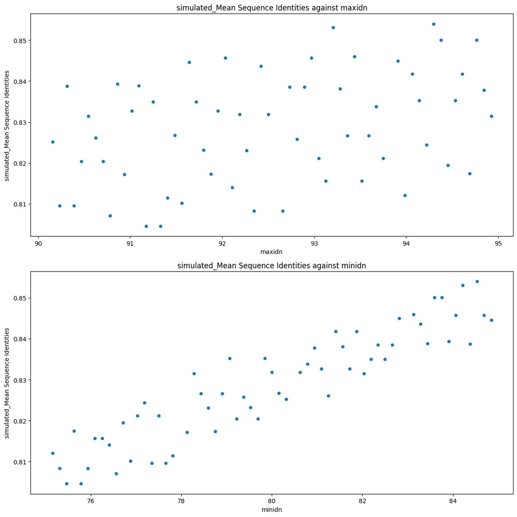

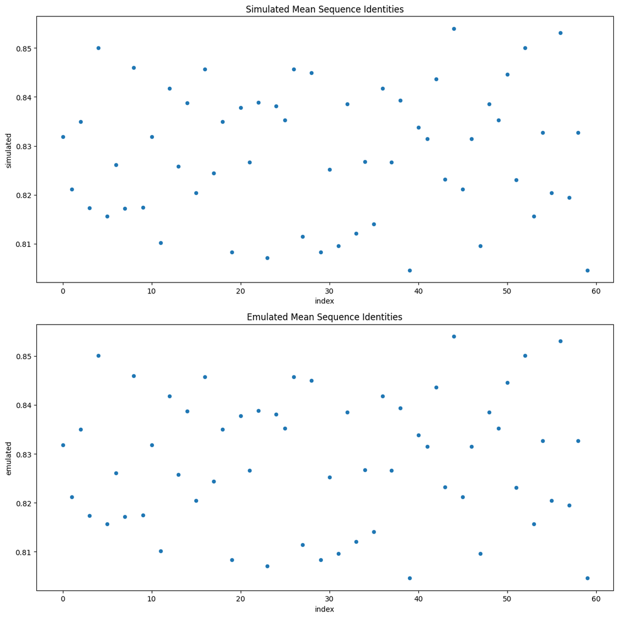

```python
specification = SurrogateModelMethodModel(
	experiment_name="sklearn_surrogate_modelling",
	parameter_spec=parameter_spec,
	method="gp",
    outdir="data",
	n_samples=60,
    use_shap=True,
    output_labels=["Mean Sequence Identities"],
	batched=False,
)

calibrator = SurrogateModelMethod(
	calibration_func=surrogate_modelling_func,
	specification=specification,
	engine="sklearn",
)

calibrator.specify().execute().analyze()
surrogate = calibrator.get_emulator()
```

```
(-0.5, 799.5, 228.5, -0.5)
```

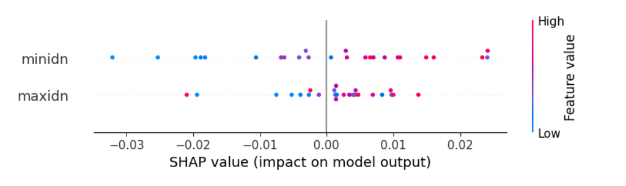

```python
import matplotlib.image as mpimg
import matplotlib.pyplot as plt

img = mpimg.imread('data/2025-10-10-03-45-40-surrogate_modelling-sklearn_surrogate_modelling-param-importances.png')

plt.figure(figsize=(15, 15))
plt.imshow(img)
plt.axis('off')
```

There is a relatively clear positive relationship between minidn and the mean sequence identities.

Larger values of minidn push the predicted value of mean sequence identity above the base (what the model predicts on average if you know nothing about the specific instance). Smaller values of minidn push the predicted value of mean sequence identity below the base

There's a similar pattern with maxidn but with greater mixing closer to the base.